# Full description of the two region model

Emma Holmes

2019-05-01

## Packages

Begin by loading the `deSolve` package needed for the differential equation solver.

```r
# Packages
library("deSolve")
```

## Graphical options

```r
par(las=1)
```

**BMB**: consider setting palette here too instead of hard-coding colours below (`?palette`)

## Parameters

Parameters are written as a vector, which will be called by the simulation function.

**BMB**: might be better to store this information externally (e.g. in a CSV file?)

```r
Params <- pars <- c(
  #==========================================================================
  ## MACROECONOMIC MODULE
  # Population dynamics
  max_N_N    = 7.056,    # Ceiling on global workforce, in billions
  delta_N_N  = 0.02,     # Speed of growth of of workforce dynamics
  max_N_S    = 7.056,    # (same for the South)
  delta_N_S  = 0.02,

  # Productivity
  alpha_N        = 0.02,     # Growth rate of labour productivity (constant)
  alpha_S        = 0.02,
  alpha_1        = 0.0072,   # productivity growth parameter, Burke et al.(2015)
  alpha_2        = -0.0004,  # productivity growth parameter, Burke et al.(2015)

  # Wages - Phillips curve
  Phill_lin_const   = -0.292,   # constant of linear Phillips curve - AFD
  Phill_slope       = 0.469,    # slope of linear Phillips curve - AFD
  Phill_denom       = 0.04^3 / (1 - 0.04^2),  # Grasselli & Costa Lima (2012)
  Phill_asymp_const = -0.04 / (1 - 0.04^2),   # Grasselli & Costa Lima (2012)

  # Capital
  delta          = 0.04,    # Depreciation rate of capital
  nu             = 2.7,     # Capital to output ration (constant)

  # Divided function
  div_constant    = 0.0513,   # from Mc Isaac
  div_slope       = 0.4729,   # from Mc Isaac
  div_min         = 0,
  div_max         = 1,

  # Investment function
  I_lin_constant = 0.0318,   # constant of linear investment function
  I_lin_slope    = 0.5753,   # slope of linear investment function
  I_lin_max      = 0.3,
  I_lin_min      = 0,

  # Interest rate
  r_longtarget   = 0.01,
  r_taylor       = 0.5,
  i_target       = 0.02,

  #Inflation
  eta            = 0.3,    # Relaxation parameter of inflation
  conv10to15     = 1.160723971/1000,
  mu             = 1.2,
  omitted        = 0.3,

  #Banking sector
  s_rep         = 0.1,
  CR_0          = 0.17,
  CR_lev        = 0.1,
  multiply      = 1/.8,

  #==========================================================================
  ## DAMAGES
  f_Dam_k       = 0,     # Fraction of damages allocated to capital
  dam_exp       = 6.754, # Parameter for damage function
  dam_1         = 0,     # Damage function parameter, in  per degrees Celsius
  dam_2         = 0.00236,  # Damage function parameter, in  per degrees Celsius squared
  dam_weitzman  = 0.00000507,  # Damage function parameter, in  per degrees Celsius to the power of damage_exp
  dam_stern     = 0.0000819,

  #==========================================================================
  ## CLIMATE MODULE
  # C02 levels
  CO2_AT_preind = 588, # preindustrial concentration of CO2 in the
  # atmosphere layer, in Gt C
  CO2_UP_preind = 360, # preindustrial concentration of CO2 in the
  # biosphere and upper ocean layer, in Gt C
  CO2_LO_preind = 1720, # preindustrial concentration of CO2 in the
  # lower ocean layer, in Gt C
  phi_12 = 0.0239069, #0.024,  # Transfer coefficient for carbon from the
  # atmosphere to the upper ocean and biosphere
  phi_23 = 0.0013409, #0.001,  # Transfer coefficient for carbon from the upper
    # ocean and biosphere to the lower ocean

  # CO2 emissions
  delta_E_land = -0.022, # Growth rate of land use change CO2-e emissions
  delta_g_sigma = -0.001, # Variation rate of the growth of emission intensity

  # Radiative Forcing
  F2xCO2 = 3.6813, #3.681, # Change in radiative forcing resulting from a
    # doubling of CO2 concentration from preindustrial levels, in W/m^2
  F_exo_start = 0.5, # Value of exogenous radiative forcing in 2016
  F_exo_end = 1, # Value of exogenous radiative forcing in 2100
  F_exo_start_year = 2016,
  F_exo_end_year = 2100,

  # Temperature
  T_preind = 13.74,  # Preindustrial temperature, in degrees Celsius
  C_init = 1/0.098,  # Heat capacity of the atmosphere, biosphere,
  # and upper ocean, in SI
  C0 = 3.52,  # Heat capacity of the deeper ocean
  gamma_star = 0.0176, # Heat exchange coefficient between temperature layers, in SI
  S = 3.1,  # Equilibrium climate sensitivity, in degrees Celsius

  #==========================================================================
  ## CARBON PRICE AND BACKSTOP
  theta_2 = 2.6, # Abatement cost function parameter
  g_p_BS = -0.0051, #-0.005, # Exogenous growth rate of the price of backstop technology
  s_A = 0,
  n_init = 0.03,
  beta_C        = 0.0124,
  S_ref         = 2.9,

  # Carbon price settings
  p_Car_step_year_1 = 2020,
  p_Car_step_year_2 = 2030,
  p_Car_L_val_1 = 40,
  p_Car_L_val_2 = 50,
  p_Car_M_val_1 = 50,
  p_Car_M_val_2 = 80,
  p_Car_H_val_1 = 80,
  p_Car_H_val_2 = 100,
  p_Car_C_val_1 = 22,
  p_Car_C_val_2 = 90,

  p_Car_L_val_3 = 120,
  p_Car_M_val_3 = 150,
  p_Car_H_val_3 = 200,
  p_Car_C_val_3 = 150
  )
```

## Functions

To simplify the simulation function, separate functions are written to compute aspects of the modules.

### Macroeconomic module

#### Production function

Production depends on capital according to $Y := K / \nu$ where $\nu$ is the capital-to-output ratio (a parameter).

```r
f_prod <- function(K, pars) {
  Y <- K/pars['nu']
  return(Y)
}
```

##### Phillips curve

The Phillips curve gives the relationship between employment and wages. It is assumed that employees can influence their wages by bargaining, so at higher employment levels wage changes are higher (employees are in high demand), and at lower employment levels wage changes are lowers (employees have to compete more for jobs).

```r
f_phill <- function(lambda, pars, active){
  switch(active$Phillips,
         'linear' = pars['Phill_slope'] * lambda + pars['Phill_lin_const'],
         'asymptotic' = pars['Phill_denom'] / ((1 - lambda)^2) + pars['Phill_asymp_const']
         )
}
```

#### Dividend function

Dividends are a linear function of the firm’s return on assets. The function is constrained to return a dividend fraction between 0 and 1 (inclusive).

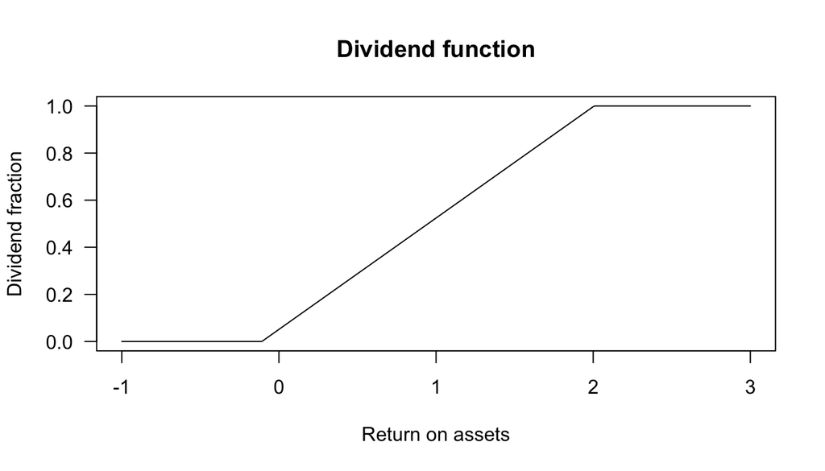

```r
f_div <- function(pi, pars) {
  div <- pmax(pars['div_min'], pmin(pars['div_max'], pars['div_constant'] + pars['div_slope']*pi))
  return(div)
}
```

#### Investment function

Similarly, the investment function is an increasing linear function, this time constrained to be between 0 and 0.3

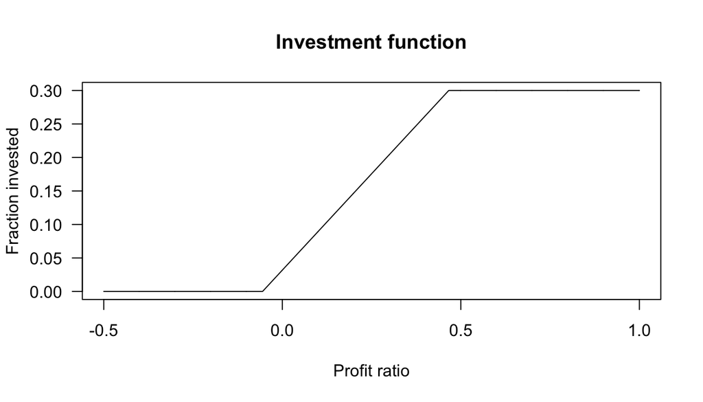

```r
# Linear investment function
f_inv <- function(pi, pars) {
  inv <- pmax(pars['I_lin_min'], pmin(pars['I_lin_max'], pars['I_lin_constant']+pars['I_lin_slope']*pi))
  return(inv)
}
```

#### Credit rationing function

We assume that banks satisfy firms’ demand for credit based on the firm’s leverage ratio, according to the following function:

```r
f_credit <- function(lev, pars) {
  CR <- ifelse(lev > 0, pmax(0,pmin(pars['CR_0'] + pars['CR_lev'] * lev,1)), 1)
  return(CR)
}
```

#### Taylor’s rule

We assume that there is a central bank that sets interest rates. It follows Taylor’s rule, so the interest rate is set according to $r_i = \max{\{0, r^*_i + i_i + \phi_i (i_i - i^*_i)\}}$ , where $r^*_i$ is the long-term interest rate, $i^*_i$ is the target inflation rate determined by the central bank, and $\phi_i$ is a parameter that represents the magnitude of the central bank’s response to inflation:

```r
f_taylor <- function(infl, pars) {
  taylor <- pmax(0, pars['r_longtarget'] - pars['r_taylor']*pars['i_target'] + (1+pars['r_taylor'])*infl)
  return(taylor)
}
```

#### Workforce growth

This function computes the gradient for the workforce dynamics. The workforce grows logistically.

```r
f_workforce <- function(N, delta, max) {
  d_N <- delta*N*(1 - N/max)
  return(d_N)
}
```

#### Labour productivity

There are two possibilities for the dynamics of labour productivity. In the standard specification (`"constant"`), the gradient of labour productivity is a constant (ie. labour productivity grows exponentially). Alternatively, one can implement the `"Burke"` specification (Burke et al., 2015). Here, one assumes that the deviation in temperature affects the productivity of labour according to a quadratic specification: $\dot{a} = a \left[ \alpha_1 (T_{preind} + T) + \alpha_2 (T_{preind} + T)^2 \right]$. This specification can be used as an alternative to assigning damages to output and/or labour.

```r
f_labour_prod_N <- function(a, Temp, pars, active) {
  switch(active$Lab_Prod_N,
         "constant" = a * pars['alpha_N'],
         "Burke"    = a * (pars['alpha_1'] * (pars['T_preind'] + Temp) +
                             pars['alpha_2'] * (pars['T_preind'] + Temp)^2)
         )
}

f_labour_prod_S <- function(a, Temp, pars, active) {
  switch(active$Lab_Prod_S,
         "constant" = a * pars['alpha_S'],
         "Burke"    = a * (pars['alpha_1'] * (pars['T_preind'] + Temp) +
                             pars['alpha_2'] * (pars['T_preind'] + Temp)^2)
  )
}
```

### Climate module

#### Radiative forcing

We assume that radiative forcing increases exogenously over time. It follows a linear path, where the start and end values are set parameters.

```r
# Exogenous forcing function
f_F_exo <- function(t, pars) {
  current_time <- t + pars['F_exo_start_year']
  future <- pars['F_exo_end_year'] - pars['F_exo_start_year']
  if(as.numeric(current_time) <= pars['F_exo_end_year']) {
    F_exo_slope <- (pars['F_exo_end'] - pars['F_exo_start'])/future
    F_exo <- pars['F_exo_start'] + t*F_exo_slope
  } else {
    F_exo <- pars['F_exo_end']
  }
  return(F_exo)
}

# Exogenous forcing (vector input)
f_F_exo_vec <- function(t, pars) {
  n_steps <- length(t)
  F_exo <- rep(0, n_steps)
  for (k in 1:n_steps) {
    F_exo[k] <- f_F_exo(t = t[k], pars = pars)
  }
  return(F_exo)
}
```

Industrial forcing depends on the concentration of CO$_2$ in the atmosphere according to: $F_{ind} := \frac{F_{dbl}}{\text{log}(2)} \text{log} \left( \frac{CO_2^{AT}}{C_{AT_{preind}}}\right)$.

```r
# Industrial radiative forcing function
f_F_ind <- function(CO2_AT, pars) {
  F_ind <- (pars['F2xCO2']/log(2))*log(CO2_AT/pars['CO2_AT_preind'])
  return(F_ind)
}
```

### Damage Curves

Damages can be assigned to output and/or capital. The damage curve computes the percentage damage according to the deviation in temperature from pre-industrial levels. The damage curve takes the form $\textbf{D}_i = 1 - \frac{1}{1 + \xi_{1_i} T + \xi_{2_i} T^2 + \xi_{3_i} T^{\zeta_i}}$. There are three possible damage specifications that one can choose from (`"Nordhaus"`, `"Weitzman"`, and `"Stern"`). The curves are shown in the figure below.

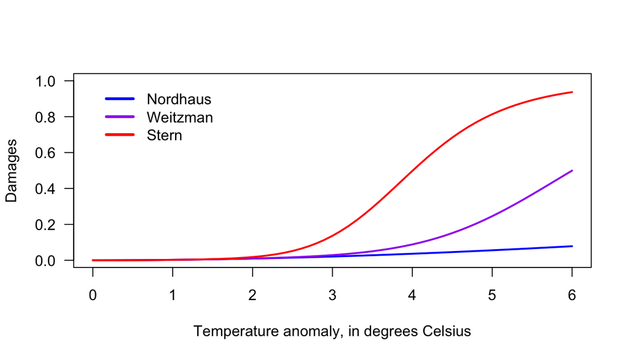

The code computes the damage according to the specified damage function, and then splits the damages between capital and output according to the fraction specified by `active$Damage_K`.

```r
# Climate Damage Functions
f_Dam_N <- function(Temp, pars, active) {
  switch(active$Damage_N,
         'None' = 0 * Temp,
         'Nordhaus' = 1 - 1/(1 + pars['dam_1'] * Temp + pars['dam_2'] * Temp^2),
         'Weitzman' = 1 - 1/(1 + pars['dam_1'] * Temp + pars['dam_2'] * Temp^2 +
                               pars['dam_weitzman'] * Temp^pars['dam_exp']),
         'Stern' = 1 - 1/(1 + pars['dam_1'] * Temp + pars['dam_2'] * Temp^2 +
                            pars['dam_stern']*Temp^pars['dam_exp'])
  )
}

f_Dam_S <- function(Temp, pars, active) {
  switch(active$Damage_S,
         'None' = 0 * Temp,
         'Nordhaus' = 1 - 1/(1 + pars['dam_1'] * Temp + pars['dam_2'] * Temp^2),
         'Weitzman' = 1 - 1/(1 + pars['dam_1'] * Temp + pars['dam_2'] * Temp^2 +
                               pars['dam_weitzman'] * Temp^pars['dam_exp']),
         'Stern' = 1 - 1/(1 + pars['dam_1'] * Temp + pars['dam_2'] * Temp^2 +
                            pars['dam_stern']*Temp^pars['dam_exp'])
  )
}

# Damages allocated to output
f_Dam_Y <- function(Dam, pars, active) {
 D_Y <- Dam * (1 - active$Damage_K)
 return(D_Y)
}

# Damages allocated to capital
f_Dam_K <- function(Dam, pars, active) {
  D_K <- active$Damage_K * Dam
  return(D_K)
}
```

### Carbon pricing

The carbon price function is written as a linear function with two kinks. The price grows from the initial position to a preset level in 2020, then to a preset level in 2030, and finally to a preset level in 2100. The function is written to implement four possible schemes:

| Scenario | 2020 | 2030 | 2100 |
| --- | --- | --- | --- |
| Low | $40 | $50 | $120 |
| Medium | $50 | $80 | $150 |
| High | $80 | $100 | $200 |
| Canada | $22 | $90 | $150 |

```r
f_p_Car_N <- function(p_Car,pars,active,time,state){
  # the price of carbon cannot be greater than the price of the backstop technology
  if(p_Car >= state[['p_BS']]) {
    p_Car = state[['p_BS']]
  }
  # first, check that carbon pricing has started
  if(state[['counter']] >= (time['start_p_Car_N'] - time['start'])){
    # set emissions reduction rate
    n_N         <- min((p_Car  / ((1 - active$s_A_N) * state['p_BS']))^
                         (1 / (pars['theta_2'] - 1)), 1)

    # Low carbon pricing scheme:
    if (active$p_Car_N == 'Low'){
      if (state['counter'] <= (pars[['p_Car_step_year_1']] - time['start_p_Car_N'])) {
        d_p_Car_N    <- (pars[['p_Car_L_val_1']] - pars['p_Car_N_start']) /
          (pars[['p_Car_step_year_1']] - time['start_p_Car_N'])
      } else if (state['counter'] <= (pars[['p_Car_step_year_2']] - pars[['p_Car_step_year_1']])){
        d_p_Car_N  <- (pars[['p_Car_L_val_2']] - pars[['p_Car_L_val_1']]) /
          (pars[['p_Car_step_year_2']] - pars[['p_Car_step_year_1']])
      } else {
        d_p_Car_N <- (pars[['p_Car_L_val_3']] - pars[['p_Car_L_val_2']]) /
          (time['end'] - pars[['p_Car_step_year_2']])
      }

      # Medium carbon pricing scheme:
    } else if (active$p_Car_N == 'Medium'){
      if (state['counter'] <= (pars[['p_Car_step_year_1']] - time['start_p_Car_N'])) {
        d_p_Car_N    <- (pars[['p_Car_M_val_1']] - pars['p_Car_N_start']) /
          (pars[['p_Car_step_year_1']] - time['start_p_Car_N'])
      } else if (state['counter'] <= (pars[['p_Car_step_year_2']] - pars[['p_Car_step_year_1']])){
        d_p_Car_N  <- (pars[['p_Car_M_val_2']] - pars[['p_Car_M_val_1']]) /
          (pars[['p_Car_step_year_2']] - pars[['p_Car_step_year_1']])
      } else {
        d_p_Car_N <- (pars[['p_Car_M_val_3']] - pars[['p_Car_M_val_2']]) /
          (time['end'] - pars[['p_Car_step_year_2']])
      }

      # High carbon pricing scheme:
    }  else if (active$p_Car_N == 'High'){
      if (state['counter'] <= (pars[['p_Car_step_year_1']] - time['start_p_Car_N'])) {
        d_p_Car_N    <- (pars[['p_Car_H_val_1']] - pars['p_Car_N_start']) /
          (pars[['p_Car_step_year_1']] - time['start_p_Car_N'])
      } else if (state['counter'] <= (pars[['p_Car_step_year_2']] - pars[['p_Car_step_year_1']])){
        d_p_Car_N  <- (pars[['p_Car_H_val_2']] - pars[['p_Car_H_val_1']]) /
          (pars[['p_Car_step_year_2']] - pars[['p_Car_step_year_1']])
      } else {
        d_p_Car_N <- (pars[['p_Car_H_val_3']] - pars[['p_Car_H_val_2']]) /
          (time['end'] - pars[['p_Car_step_year_2']])
      }

      # Canadian federal backstop carbon pricing scheme
      } else if (active$p_Car_N == 'Canada'){
        if (state['counter'] <= (pars[['p_Car_step_year_1']] - time['start_p_Car_N'])) {
          d_p_Car_N    <- (pars[['p_Car_C_val_1']] - pars['p_Car_N_start']) /
            (pars[['p_Car_step_year_1']] - time['start_p_Car_N'])
        } else if (state['counter'] <= (pars[['p_Car_step_year_2']] - pars[['p_Car_step_year_1']])){
          d_p_Car_N  <- (pars[['p_Car_C_val_2']] - pars[['p_Car_C_val_1']]) /
            (pars[['p_Car_step_year_2']] - pars[['p_Car_step_year_1']])
        } else {
          d_p_Car_N <- (pars[['p_Car_C_val_3']] - pars[['p_Car_C_val_2']]) /
            (time['end'] - pars[['p_Car_step_year_2']])
        }

        # No carbon pricing
      }  else if (active$p_Car_N == 'None'){
        d_p_Car_N   <- pars[['g_p_BS']] * p_Car

        # if carbon pricing hasn't started yet
      }} else {
        n_N         <- pars[['n_N_init']]
        d_p_Car_N   <- pars[['g_p_BS']] * p_Car
      }
  # return emissions reduction rate and carbon pricing gradient
  res <- data.frame(
    n_N = n_N,
    d_p_Car_N = d_p_Car_N
  )
  return(res)
}
```

A separate (but identical) carbon pricing function is given for the South, so that the two regions may have different carbon pricing schemes.

```r
f_p_Car_S <- function(p_Car,pars,active,time,state){
  # the price of carbon cannot be greater than the price of the backstop technology
  if(p_Car >= state[['p_BS']]) {
    p_Car = state[['p_BS']]
  }
  # first, check that carbon pricing has started
  if(state[['counter']] >= (time['start_p_Car_S'] - time['start'])){
    # set emissions reduction rate
    n_S         <- min((p_Car  / ((1 - active$s_A_S) * state['p_BS']))^
                         (1 / (pars['theta_2'] - 1)), 1)

    # Low carbon pricing scheme
    if (active$p_Car_S == 'Low'){
      if (state['counter'] <= (pars[['p_Car_step_year_1']] - time['start_p_Car_S'])) {
        d_p_Car_S    <- (pars[['p_Car_L_val_1']] - pars['p_Car_S_start']) /
          (pars[['p_Car_step_year_1']] - time['start_p_Car_S'])
      } else if (state['counter'] <= (pars[['p_Car_step_year_2']] - pars[['p_Car_step_year_1']])){
        d_p_Car_S  <- (pars[['p_Car_L_val_2']] - pars[['p_Car_L_val_1']]) /
          (pars[['p_Car_step_year_2']] - pars[['p_Car_step_year_1']])
      } else {
        d_p_Car_S <- (pars[['p_Car_L_val_3']] - pars[['p_Car_L_val_2']]) /
          (time['end'] - pars[['p_Car_step_year_2']])
      }

      # Medium carbon pricing scheme
    } else if (active$p_Car_S == 'Medium'){
      if (state['counter'] <= (pars[['p_Car_step_year_1']] - time['start_p_Car_S'])) {
        d_p_Car_S    <- (pars[['p_Car_M_val_1']] - pars['p_Car_S_start']) /
          (pars[['p_Car_step_year_1']] - time['start_p_Car_S'])
      } else if (state['counter'] <= (pars[['p_Car_step_year_2']] - pars[['p_Car_step_year_1']])){
        d_p_Car_S  <- (pars[['p_Car_M_val_2']] - pars[['p_Car_M_val_1']]) /
          (pars[['p_Car_step_year_2']] - pars[['p_Car_step_year_1']])
      } else {
        d_p_Car_S <- (pars[['p_Car_M_val_3']] - pars[['p_Car_M_val_2']]) /
          (time['end'] - pars[['p_Car_step_year_2']])
      }

      # High carbon pricing scheme
    }  else if (active$p_Car_S == 'High'){
      if (state['counter'] <= (pars[['p_Car_step_year_1']] - time['start_p_Car_S'])) {
        d_p_Car_S    <- (pars[['p_Car_H_val_1']] - pars['p_Car_S_start']) /
          (pars[['p_Car_step_year_1']] - time['start_p_Car_S'])
      } else if (state['counter'] <= (pars[['p_Car_step_year_2']] - pars[['p_Car_step_year_1']])){
        d_p_Car_S  <- (pars[['p_Car_H_val_2']] - pars[['p_Car_H_val_1']]) /
          (pars[['p_Car_step_year_2']] - pars[['p_Car_step_year_1']])
      } else {
        d_p_Car_S <- (pars[['p_Car_H_val_3']] - pars[['p_Car_H_val_2']]) /
          (time['end'] - pars[['p_Car_step_year_2']])
      }

      # Canadian federal backstop carbon pricing scheme
      } else if (active$p_Car_S == 'Canada'){
        if (state['counter'] <= (pars[['p_Car_step_year_1']] - time['start_p_Car_S'])) {
          d_p_Car_S    <- (pars[['p_Car_C_val_1']] - pars['p_Car_S_start']) /
            (pars[['p_Car_step_year_1']] - time['start_p_Car_S'])
        } else if (state['counter'] <= (pars[['p_Car_step_year_2']] - pars[['p_Car_step_year_1']])){
          d_p_Car_S  <- (pars[['p_Car_C_val_2']] - pars[['p_Car_C_val_1']]) /
            (pars[['p_Car_step_year_2']] - pars[['p_Car_step_year_1']])
        } else {
          d_p_Car_S <- (pars[['p_Car_C_val_3']] - pars[['p_Car_C_val_2']]) /
            (time['end'] - pars[['p_Car_step_year_2']])
        }

        # no carbon pricing
      }  else if (active$p_Car_S == 'None'){
        d_p_Car_S   <- pars[['g_p_BS']] * p_Car

        # if the carbon price is not yet in effect
      }} else {
        n_S         <- pars[['n_S_init']]
        d_p_Car_S   <- pars[['g_p_BS']] * p_Car
      }

  # return emissions reduction rate and carbon price gradient
  res <- data.frame(
    n_S = n_S,
    d_p_Car_S = d_p_Car_S
  )
  return(res)
}
```

Finally all functions are stored in a vector.

```r
# Return functions as a list
listfunc <- c('f_prod',
              'f_phill',
              'f_div',
              'f_inv',
              'f_credit',
              'f_taylor',
              'f_workforce',
              'f_labour_prod_N',
              'f_labour_prod_S',
              'f_F_exo',
              'f_F_exo_vec',
              'f_F_ind',
              'f_Dam_N',
              'f_Dam_S',
              'f_Dam_Y',
              'f_Dam_K',
              'f_p_Car_S',
              'f_p_Car_N'
)
```

## Simulation setup

To run a simulation, one must begin by specifying initial conditions:

```r
IC <- c(
  ### Separated
  # North
  Y_N       =  30,       # global GDP, in trillions of USD
  d_N       =  1.5328,   # private debt ratio of the economy
  lambda_N  =  0.6748,   # employment rate of the global economy
  omega_N   =  0.5782,   # wage share of the economy
  N_N       =  2.4127,   # Workforce of the (world) economy, in billions /2
  g_sigma_N =  -0.0105,  # Growth rate of the emissions intensity of the economy
  n_N       =  0.03,     # Emissions reduction rate
  E_ind_N   =  17.925,    # Industrial CO2-e emissions, in Gt CO2-e

  # South
  Y_S       =  30,       # global GDP, in trillions of USD
  d_S       =  1.5328,   # private debt ratio of the economy
  lambda_S  =  0.6748,   # employment rate of the global economy
  omega_S   =  0.5782,   # wage share of the economy
  N_S       =  2.4127,   # Workforce of the (world) economy, in billions /2
  g_sigma_S =  -0.0105,  # Growth rate of the emissions intensity of the economy
  n_S       =  0.03,     # Emissions reduction rate
  E_ind_S   =  17.925,    # Industrial CO2-e emissions, in Gt CO2-e

  # Unique
  CO2_AT   =  851,      # CO2-e concentration in the atmosphere layer, in Gt C
  CO2_UP   =  460,      # CO2-e concentration in the biosphere and upper ocean layer, in Gt C
  CO2_LO   =  1740,     # CO2-e concentration in the deep ocean layer, in Gt C
  E_land   =  2.6,      # Exogenous land use change CO2-e emissions, in Gt CO2-e
  p        =  1,        # Composite good price level
  p_BS     =  547.22,   # Backstop technology price level
  Temp     =  0.85,     # Temperature in the atmosphere, biosphere, and upper ocean layer, in degrees Celsius
  Temp_LO  =  0.0068    # Temperature in the deep ocean layer, in degrees Celsius
)
```

a vector specifying the first and last years for the simulation, the step size, and the start time for the carbon pricing schemes:

```r
Time <- c(
  start         =     2016,
  end           =     2100,
  step          =     0.05,
  start_p_Car_N =     2016,
  start_p_Car_S =     2016
)
```

and a list specifying the features of the run (in particular, the damage specification for North and South, the fraction of damages assigned to capital, the carbon pricing scheme and government subsidies in the North and South, the labour productivity specification in North and South, and the type of Phillips curve. One can also turn off the temperature.):

```r
Active <- list(
  Damage_N     =   'None',       # None / Nordhaus / Weitzman / Stern
  Damage_S     =   'None',       # None / Nordhaus / Weitzman / Stern
  Damage_K     =    0,           # Fraction of damages allocated to capital
  Temperature  =    TRUE,        # T / F
  Lab_Prod_N   =   'constant',   # constant / Burke
  Lab_Prod_S   =   'constant',   # constant / Burke
  p_Car_N      =   'None',       # None / Low / Medium / High / Canada
  s_A_N        =   0,            # fraction of abatement costs subsidized by government
  p_Car_S      =   'None',       # None / Low / Medium / High / Canada
  s_A_S        =   0,            # fraction of abatement costs subsidized by government
  Phillips     =   'asymptotic'  # linear / asymptotic
)
```

## System

The system boils down to 24 differential equations.

##### Each economy

Three Keen variables

- total debt in each region: $D_i$
- wages in each region: $w_i$
- labour productivity in each region: $a_i$

Auxiliary equation:

- capital stock in each region: $K_i$

Four uncoupled equations:

- workforce in each region: $N_i$
- the carbon price in each region: $p_{c_i}$
- the carbon intensity and carbon intensity growth rate: $\sigma_i$, $g_{\sigma_i}$

##### Climate

Three for the carbon cycle:

- CO$_2$ in each of the three layers: $CO_2^{AT}$, $CO_2^{UP}$, $CO_2^{LO}$

Two for temperature:

- temperature in the two layers: $T$, $T_{LO}$

One uncoupled:

- land-based emissions: $E_{land}$

##### Prices

Key coupling equation (inflation):

- the price level: $p$

One uncoupled:

- the price of the backstop (green) technology: $p_{BS}$

Of the 24 differential equations, 12 are nontrivial: the three Keen equations in each region, the three carbon equations, the two temperature equations, and the equation for the price level.

## Simulation

The model is run using the following simulation function. It begins by taking the initial conditions specified above and converting them into the necessary initial state for the differential equation solver.

```r
simulation <- function(time, init_sim, pars, active,
                       show_end_results = TRUE, show_graph = TRUE,
                       montecarlo = FALSE) {

  start_time <- proc.time()   # start timing

  #===========================================================================
  ### INITIAL STATE ####
  # Time
  time_sim      <- seq(0, time['end'] - time['start'], by = time['step'])
```

Damages are computed using the damage functions from above. Output ($Y$) is a given initial condition, as is the price level (set to one initially). The initial value of the exogenous radiative forcing is a parameter.

```r
  ### Initial values
  # Damages
  Dam_N_init     <- f_Dam_N(Temp = init_sim[['Temp']], pars = pars, active = active)
  Dam_Y_N_init   <- f_Dam_Y(Dam = Dam_N_init, pars = pars, active = active)

  Dam_S_init     <- f_Dam_S(Temp = init_sim[['Temp']], pars = pars, active = active)
  Dam_Y_S_init   <- f_Dam_Y(Dam = Dam_S_init, pars = pars, active = active)

  # need totals
  Y_init         <- init_sim[['Y_N']] + init_sim[['Y_S']]
  Dam_Y_init     <- Dam_Y_N_init + Dam_Y_S_init

  # other variables (unique)
  p_init         <- as.numeric(init_sim[['p']])
  F_exo_init     <- as.numeric(pars[['F_exo_start']])
```

The initial level of the carbon tax is computed using the following relationship: $n_i = \left(\frac{p_{C_i}}{(1 - s_{A_i}) p_{BS_i}}\right)^\frac{1}{\theta - 1}$

The initial abatement cost (A) is computed according to $A_i := \frac{\sigma_i \: p_{BS}}{1000 \theta} \: n^\theta_i$

```r
  # emission reduction - North
  p_Car_N_init   <- init_sim[['n_N']]^(pars[['theta_2']] - 1) *
    (1 - active$s_A_N) * init_sim[['p_BS']]
  sigma_N_init   <- init_sim[['E_ind_N']] / ((1 - init_sim[['n_N']]) * init_sim[['Y_N']])
  A_N_init       <- (sigma_N_init * init_sim[['p_BS']] / (1000 * pars[['theta_2']])) *
    init_sim[['n_N']]^pars[['theta_2']]

  # emission reduction - South
  p_Car_S_init   <- init_sim[['n_S']]^(pars[['theta_2']] - 1) *
    (1 - active$s_A_S) * init_sim[['p_BS']]
  sigma_S_init     <- init_sim[['E_ind_S']] / ((1 - init_sim[['n_S']]) * init_sim[['Y_S']])
  A_S_init         <- (sigma_S_init * init_sim[['p_BS']] / (1000 * pars[['theta_2']])) *
    init_sim[['n_S']]^pars[['theta_2']]
```

Initial capital levels are calculated by rearranging the following two equations: $Y_i := (1 - \mathbf{D}^Y_i)(1 - A_i)Y^0_i$ ; $Y^0_i := \frac{K_i}{\nu_i}$.

```r
  # different capital in North and South
  K_N_init       <- pars[['nu']] * init_sim[['Y_N']] / ((1 - Dam_Y_N_init) * (1 - A_N_init))
  K_S_init       <- pars[['nu']] * init_sim[['Y_S']] / ((1 - Dam_Y_S_init) * (1 - A_S_init))
```

The debt ratio ($d$) is converted to total nominal debt ($D$) for the differential equation solver.

```r
  # different debt levels
  D_N_init       <- init_sim[['d_N']] * p_init * init_sim[['Y_N']]
  D_S_init       <- init_sim[['d_S']] * p_init * init_sim[['Y_S']]
```

Total employed persons ($L$) is computed from the employment rate ($\lambda$) and the workforce ($N$), wages are computed using the relationship $\omega_i := \frac{w_i L_i}{p Y_i}$, and labour productivity is computed using $L_i := \frac{Y^0_i}{a_i}$.

```r
  # different employment
  L_N_init    <- init_sim[['lambda_N']] * init_sim[['N_N']]
  w_N_init    <- init_sim[['omega_N']] * p_init * init_sim[['Y_N']] / L_N_init
  a_N_init    <- init_sim[['Y_N']] / ((1 - Dam_Y_N_init) * (1 - A_N_init) * L_N_init)

  L_S_init    <- init_sim[['lambda_S']] * init_sim[['N_S']]
  a_S_init    <- init_sim[['Y_S']] / ((1 - Dam_Y_S_init) * (1 - A_S_init) * L_S_init)
  w_S_init    <- init_sim[['omega_S']] * p_init * init_sim[['Y_S']] / L_S_init
```

```r
  C           <- 5 / (1/pars[['C_init']] + pars[['beta_C']] *
                        (pars[['S']] - pars[['S_ref']]))

  pars        <- c(pars,
                   p_Car_N_start = as.numeric(p_Car_N_init),
                   p_Car_S_start = as.numeric(p_Car_S_init),
                   C = as.numeric(C),
                   n_N_init = as.numeric(init_sim[['n_N']]),
                   n_S_init = as.numeric(init_sim[['n_S']]))
```

This gives the 24 initial conditions for the differential equation solver (plus the counter).

**BMB** why do we need all of the `as.numeric()`?

```r
  state       <- c(
    K_N       = as.numeric(K_N_init),
    K_S       = as.numeric(K_S_init),
    N_N       = as.numeric(init_sim[['N_N']]),
    N_S       = as.numeric(init_sim[['N_S']]),
    D_N       = as.numeric(D_N_init),
    D_S       = as.numeric(D_S_init),
    w_N       = as.numeric(w_N_init),
    w_S       = as.numeric(w_S_init),
    a_N       = as.numeric(a_N_init),
    a_S       = as.numeric(a_S_init),
    p         = as.numeric(p_init),
    E_land    = as.numeric(init_sim[['E_land']]),
    sigma_N   = as.numeric(sigma_N_init),
    g_sigma_N = as.numeric(init_sim[['g_sigma_N']]),
    sigma_S   = as.numeric(sigma_S_init),
    g_sigma_S = as.numeric(init_sim[['g_sigma_S']]),
    CO2_AT    = as.numeric(init_sim[['CO2_AT']]),
    CO2_UP    = as.numeric(init_sim[['CO2_UP']]),
    CO2_LO    = as.numeric(init_sim[['CO2_LO']]),
    Temp      = as.numeric(init_sim[['Temp']]),
    Temp_LO   = as.numeric(init_sim[['Temp_LO']]),
    p_BS      = as.numeric(init_sim[['p_BS']]),
    p_Car_N   = as.numeric(p_Car_N_init),
    p_Car_S   = as.numeric(p_Car_S_init),
    counter   = as.numeric(0)
  )
```

Here we begin to write the system for the differential equation solver. Damages are computed as before.

```r
  ## DIFFERENTIAL SYSTEM
  # Function for deSolve:
  system <- function(t, state, parms) {

    ## Setup
    time        <- parms$time
    pars        <- parms$pars

    ## Macroeconomic Module
    # Climate damage - North
    Dam_N       <- f_Dam_N(Temp = state[['Temp']], pars = pars, active = active)
    Dam_K_N     <- f_Dam_K(Dam = Dam_N, pars = pars, active = active)
    Dam_Y_N     <- f_Dam_Y(Dam = Dam_N, pars = pars, active = active)

    # Climate damage - South
    Dam_S       <- f_Dam_S(Temp = state[['Temp']], pars = pars, active = active)
    Dam_K_S     <- f_Dam_K(Dam = Dam_S, pars = pars, active = active)
    Dam_Y_S     <- f_Dam_Y(Dam = Dam_S, pars = pars, active = active)

    # Total damages
    Dam    <- Dam_N + Dam_S
    Dam_K  <- Dam_K_N + Dam_K_S
    Dam_Y  <- Dam_Y_N + Dam_Y_S
```

The gradient for the backstop technology is given by $\dot{p_{BS}} = g_{p_{BS}} p_{BS}$. The gradient for the carbon price in each region, and each region’s emissions reduction rate, is computed using the carbon price function.

```r
    # Backstop technology price
    d_p_BS      <- pars[['g_p_BS']] * state[['p_BS']]

    # Carbon price - North
    p_Car_N_res <- f_p_Car_N(p_Car = state[['p_Car_N']] ,pars = pars,
                             active = active, time = time, state=state)
    d_p_Car_N   <- p_Car_N_res$d_p_Car_N   # carbon price gradient
    n_N         <- p_Car_N_res$n_N   # emissions reduction rate

    # Carbon price - South
    p_Car_S_res <- f_p_Car_S(p_Car = state[['p_Car_S']] ,pars = pars,
                             active = active, time = time, state=state)
    d_p_Car_S   <- p_Car_S_res$d_p_Car_S   # carbon price gradient
    n_S         <- p_Car_S_res$n_S   # emissions reduction rate
```

Initial production ($Y_0$) in each region is computed from the capital stock ($K$) using the production function. The abatement costs ($A$) and production ($Y$) are then computed as $A_i := \frac{\sigma_i \: p_{BS}}{1000 \times \theta} \: n^\theta_i$ ; $Y_i := (1 - \mathbf{D}^Y_i)(1 - A_i)Y^0_i$.

```r
    ### Production
    # North
    Y_0_N      <- f_prod(K = state[['K_N']], pars = pars)   # initial production
    A_N        <-  (state[['sigma_N']] * state[['p_BS']] /
                      (1000 * pars[['theta_2']])) * n_N^pars[['theta_2']]   # abatement costs
    Y_N        <- (1 - Dam_Y_N) * (1 - A_N) * Y_0_N   # production

    # South
    Y_0_S      <- f_prod(K = state[['K_S']], pars = pars)   # initial production
    A_S        <-  (state[['sigma_S']] * state[['p_BS']] /
                      (1000 * pars[['theta_2']])) * n_S^pars[['theta_2']]   # abatement costs
    Y_S        <- (1 - Dam_Y_S) * (1 - A_S) * Y_0_S   # production
```

Emissions are computed for the climate module. Industrial emissions in each region are given by $E_{{ind}_i} := \sigma_i (1 - n_i) Y^0_i$. The gradient for land-use emissions is $\dot{E}_{land} := \delta_{E_{land}} E_{land}$.

```r
    ### CO2 emissions
    E_ind_N  <- state[['sigma_N']] * (1 - n_N) * Y_N / ((1 - Dam_Y_N) * (1 - A_N))   # industrial emissions North
    E_ind_S  <- state[['sigma_S']] * (1 - n_S) * Y_S / ((1 - Dam_Y_S) * (1 - A_S))   # industrial emissions South
    E        <- E_ind_N + E_ind_S + state[['E_land']]   # total emissions
    d_E_land <- pars[['delta_E_land']] * state[['E_land']]   # land based emissions gradient
```

The carbon intensity in each economy decreases according to the coupled differential equations $\dot{\sigma_i} := g_{\sigma_i} \sigma_i$ $\dot{g_{\sigma_i}} := \delta_{g_{\sigma_i}} g_{\sigma_i}$.

```r
    # Emissions reduction
    d_sigma_N     <- state[['g_sigma_N']] * state[['sigma_N']]
    d_g_sigma_N   <- pars[['delta_g_sigma']] * state[['g_sigma_N']]

    d_sigma_S     <- state[['g_sigma_S']] * state[['sigma_S']]
    d_g_sigma_S   <- pars[['delta_g_sigma']] * state[['g_sigma_S']]
```

Employment is computed using the $L_i := \frac{Y^0_i}{a_i}$, and the employment rate is simply employed persons divided by the total workforce.

```r
    # Employment - North
    L_N        <- Y_N / ((1 - Dam_Y_N) * (1 - A_N) * state[['a_N']])   # total employment
    lambda_N   <- L_N / state[['N_N']]   # employment rate

    # Employment - South
    L_S        <- Y_S / ((1 - Dam_Y_S) * (1 - A_S) * state[['a_S']])   # total employment
    lambda_S   <- L_S / state[['N_S']]   # employment rate
```

The government in each region receives tax revenue based on the carbon tax, $T_{i}^C := p_{C_i} E_{{ind}_i}$, and subsidizes the abatement costs according to the subsidy rate, $S_{i}^C := s_{A_i} A_i Y^0_i$. The net transfer in each region is government expenditure (subsidies) minus revenue (from the carbon tax).

```r
    # Public sector - North
    T_G_c_N        <- (state[['p_Car_N']] * pars[['conv10to15']] * E_ind_N)   # tax revenues
    S_G_c_N        <- active$s_A_N * A_N * Y_0_N   # government subsidy
    Net_transfer_N <- S_G_c_N - T_G_c_N

    # Public sector - South
    T_G_c_S        <- (state[['p_Car_S']] * pars[['conv10to15']] * E_ind_S)   # tax revenues
    S_G_c_S        <- active$s_A_S * A_S * Y_0_S   # government subsidy
    Net_transfer_S <- S_G_c_S - T_G_c_S
```

Because it is assumed that there is a unique price in the country (to avoid discussion of exchange rates), inflation depends on the average wage in the country, total employment, and output.

We first compute $c := \frac{w_N L_N + w_S L_S}{p \: (Y_N + Y_S)}$, then inflation ($i$) is given by $i:= \eta \, (\mu (c + \iota ) - 1)$, where $\eta$, $\mu$, and $\iota$, are the relaxation parameter, the markup price, and a calibration parameter, respectively.

```r
    ### Prices
    c    <- (state[['w_S']] * L_S + state[['w_N']] * L_N) / (state[['p']] * (Y_N + Y_S))
    i    <- pars[['eta']] * (pars[['mu']] * (c + pars[['omitted']]) - 1)   # inflation
    r    <-  f_taylor(i, pars = pars)   # interest rate
    d_p  <- i * state[['p']]   # price gradient
```

Firms in each region make the following profits: $\Pi_i := p Y_i - w_i L_i - \delta_{\mathbf{D}^K_i} p K_i - r_i D_i + p \Upsilon_i$, output minus payments to labour, capital, service debt, plus net transfers from the government.

The profit ratio is computed as $\pi_i := \frac{\Pi_i}{p Y_i}$, and the return on assets is computed as $\pi_{K_i} := \Pi_i / p K_i$.

Dividends are then paid out according to the dividend function, $\Pi_{d_i} := \Delta(\pi_{K_i}) p K_i$, leaving retained profits $\Pi_{r_i} := \Pi_i - \Pi_{d_i}$.

```r
    ### Profits in the North
    Pi_N          <- state[['p']] * Y_N - state[['w_N']] * L_N - r * state[['D_N']] - (pars[['delta']] + Dam_K_N) * state[['p']] *
  state[['K_N']] + state[['p']] * Net_transfer_N   # total profits
    pi_N          <- Pi_N / (state[['p']] * Y_N)   # profit ratio
    pi_K_N        <- Pi_N / (state[['p']] * state[['K_N']])   # return on assets
    Div_N         <- f_div(pi = pi_K_N, pars = pars) * state[['p']] * state[['K_N']]   # dividend payments
    Pi_r_N        <- Pi_N - Div_N   # retained profits

   ### Profits in the South
    Pi_S          <- state[['p']] * Y_S - state[['w_S']] * L_S - r * state[['D_S']] -
      (pars[['delta']] + Dam_K_S) * state[['p']] * state[['K_S']] + state[['p']] * Net_transfer_S   # total profits
    pi_S          <- Pi_S / (state[['p']] * Y_S)   # profit ratio
    pi_K_S        <- Pi_S / (state[['p']] * state[['K_S']])   # return on assets
    Div_S         <- f_div(pi = pi_K_S, pars = pars) * state[['p']] * state[['K_S']]   # dividend payments
    Pi_r_S        <- Pi_S - Div_S   # retained profits
```

Firms demand investment according to the investment function, $I^d_i := \rho_i \: \kappa(\pi_i) Y_i$.

This leads to a demand for debt in each region of $D^d_i := p I^d_i + s_{rep_i} D_i - \delta_{\mathbf{D}^K_i} p K_i - \Pi_{r_i}$. However, banks ration credit according to the credit rationing function of the firm’s leverage ratio, $CR_i := \tau_i \left( \frac{D_i}{p K_i} \right)$.

In the end, investment is $I_i := CR_i \left(\frac{\Pi_{r_i}}{p} + \delta_{\mathbf{D}^K_i} K_i - \frac{s_{rep_i} D_i}{p}\right) + (1 - CR_i) I^d_i$, and the gradient for total debt is $\dot{D_i} := (1 - CR_i) D^d_i - s_{rep_i} D_i$.

```r
    ### Investment and indebtedness in North
    I_d_N         <- pars[['multiply']] * (f_inv(pi = pi_N, pars = pars)) * Y_N   # investment demand
    D_d_N        <- state[['p']] * I_d_N - Pi_r_N + pars[['s_rep']] * state[['D_N']] - (pars[['delta']] + Dam_K_N) * state[['p']] * state[['K_N']]   # demand for debt
    lev_N         <- state[['D_N']] / (state[['p']] * state[['K_N']])   # leverage ratio
    CR_N          <- f_credit(lev_N, pars = pars)   # credit rationing

    I_N           <- CR_N * (Pi_r_N/state[['p']] + (pars[['delta']] + Dam_K_N) * state[['K_N']] - pars[['s_rep']] * state[['D_N']] / state[['p']]) + (1 - CR_N) * I_d_N   # investment
    d_D_N         <- (1 - CR_N) * D_d_N - pars[['s_rep']] * state[['D_N']]   # gradient for debt

    ### Investment and indebtedness in South
    I_d_S         <- pars[['multiply']] * (f_inv(pi = pi_S, pars = pars)) * Y_S   # investment demand
    D_d_S         <- state[['p']] * I_d_S - Pi_r_S + pars[['s_rep']] * state[['D_S']] - (pars[['delta']] + Dam_K_S) * state[['p']] * state[['K_S']]   # demand for debt
    lev_S         <- state[['D_S']] / (state[['p']] * state[['K_S']])   # leverage ratio
    CR_S          <- f_credit(lev_S, pars = pars)   # credit rationing
    I_S           <- CR_S * (Pi_r_S/state[['p']] + (pars[['delta']] + Dam_K_S) * state[['K_S']]- pars[['s_rep']] * state[['D_S']] / state[['p']]) + (1 - CR_S) * I_d_S   # investment
    d_D_S         <- (1 - CR_S) * D_d_S - pars[['s_rep']] * state[['D_S']]   # gradient for debt
```

The gradient for wages is the product of the wage and the Phillips curve, $\dot{w_i} := w_i \: \varphi_i (\lambda_i)$, where $\varphi$ is the Phillips curve and $\lambda$ is employment.

The gradient for capital is investment minus depreciation, so $\dot{K_i} := I_i - \delta_{\mathbf{D}^K_i} K_i$, where $I$ is investment, and $\delta_{\mathbf{D}^K_i}$ is depreciation including climate damages to capital.

The gradient for labour productivity is given by the labour productivity function defined above. In the standard specification, labour productivity growth is exponential, $\dot{a_i} := \alpha_i \: a_i$.

Finally, the workforce grows logistically. Its gradient is $\dot{N_i} := \delta_{N_i} N_i \left(1 - \frac{N_i}{\overline{N}_i}\right)$, where $\delta_{N_i}$ is the growth rate of each region’s workforce and $\overline{N_i}$ represents the upper limit of each region’s workforce. This differential equation is not coupled to the rest of the system.

```r
    ### Wages, capital, workforce - North
    d_w_N   <- f_phill(lambda = lambda_N, pars = pars, active = active) * state[['w_N']]
    d_K_N   <- I_N - (pars[['delta']] + Dam_K_N) * state[['K_N']]
    d_a_N     <- f_labour_prod_N(a = state[['a_N']], Temp = state[['Temp']],
                                 pars = pars, active = active)
    d_N_N   <- f_workforce(N = state[['N_N']], delta = pars[['delta_N_N']],
                           max = pars[['max_N_N']])

    ### Wages, capital, workforce - South
    d_w_S   <- f_phill(lambda = lambda_S, pars = pars, active = active) * state[['w_S']]
    d_K_S   <- I_S - (pars[['delta']] + Dam_K_S) * state[['K_S']]
    d_a_S     <- f_labour_prod_S(a = state[['a_S']], Temp = state[['Temp']],
                                 pars = pars, active = active)
    d_N_S   <- f_workforce(N = state[['N_S']], delta = pars[['delta_N_S']],
                           max = pars[['max_N_S']])
```

Now we turn to the differential equations for climate. The carbon cycle is modeled in three layers. CO$_2$ emissions can accumulate in the atmosphere ($\text{CO}_2^{AT}$), the upper ocean and biosphere ($\text{CO}_2^{UP}$), or the lower ocean ($\text{CO}_2^{LO}$). CO$_2$ accumulation evolves according to:

$$\begin{pmatrix}
\dot{\text{CO}_2}^{AT} \\
\dot{\text{CO}_2}^{UP} \\
\dot{\text{CO}_2}^{LO}
\end{pmatrix}
=
\begin{pmatrix}
E_T \\
0 \\
0
\end{pmatrix}
+
\begin{pmatrix}
-\phi_{12} & \phi_{12} C_{UP}^{AT} & 0 \\
\phi_{12} & -\phi_{12} C_{UP}^{AT} - \phi_{23} & \phi_{23} C_{LO}^{UP} \\
0 & \phi_{23} & -\phi_{23} C_{LO}^{UP}
\end{pmatrix}
\begin{pmatrix}
\text{CO}_2^{AT} \\
\text{CO}_2^{UP} \\
\text{CO}_2^{LO}
\end{pmatrix}$$

where $C_i^j = \frac{C_{j_{preind}}}{C_{i_{preind}}}$ for $i,j \in \{AT,UP,LP\}$ and $\phi_{12}$, $\phi_{23}$ are parameters.

Below, the vectors for emissions and CO$_2$ are constructed, then the gradients for CO$_2$ in each layer are obtained from the matrix multiplication.

```r
    ### Climate Module
    # CO2 accumulation
    C02         <- matrix(c(state[['CO2_AT']],state[['CO2_UP']],
                          state[['CO2_LO']]),3,1)
    # Emissions
    Emissions   <- matrix(c(as.numeric(E)/3.666,0,0),3,1)

    # Carbon cycle
    Diffusion   <- matrix(c(-pars[['phi_12']], pars[['phi_12']] *
                              (pars[['CO2_AT_preind']] / pars[['CO2_UP_preind']]),
                            0, pars[['phi_12']], -pars[['phi_12']] *
                              (pars[['CO2_AT_preind']] / pars[['CO2_UP_preind']]) -
                              pars[['phi_23']], pars[['phi_23']] *
                              (pars[['CO2_UP_preind']] / pars[['CO2_LO_preind']]),
                            0, pars[['phi_23']], -pars[['phi_23']] *
                              (pars[['CO2_UP_preind']] / pars[['CO2_LO_preind']])),
                          3,3,byrow = TRUE)

    # compute C02 gradients
    d_C02       <- Emissions + Diffusion %*% C02

    d_CO2_AT    <- d_C02[1,1]
    d_CO2_UP    <- d_C02[2,1]
    d_CO2_LO    <- d_C02[3,1]
```

Radiative forcing is computed using the functions defined above. Then the differential equations for the two temperature layers are given by
$$\dot{T} = \frac{F - \frac{F_{dbl}}{S} T - \gamma^{*} (T - T_{LO} )}{C}$$
$$\dot{T_{LO}} = \frac{\gamma^{*} (T - T_{LO} )}{C_{LO}}$$
where $C$ and $C_{LO}$ are the heat capacities of each layer, while $\gamma^*$ is a parameter representing the heat exchange between layers, and $S$ is the equilibrium climate sensitivity parameter.

```r
    # Radiative forcing
    F_exo       <- f_F_exo(t = state[['counter']], pars = pars)
    Forcing     <- f_F_ind(CO2_AT = state[['CO2_AT']], pars = pars) + F_exo

    # Temperature change
    d_Temp      <- (active$Temperature == T)*
      (Forcing/pars[['C']] - pars[['F2xCO2']]/
         (pars[['C']] * pars[['S']]) * state[['Temp']] -
         (pars[['gamma_star']] / pars[['C']]) *
         (state[['Temp']] - state[['Temp_LO']]))

    d_Temp_LO   <- (active$Temperature == T)*
      ((pars[['gamma_star']] / pars[['C0']]) * (state[['Temp']] -
                                                  state[['Temp_LO']]))
```

Finally, we increase the counter and return a list of the 24 (plus counter) differential equations for the differential equation solver.

```r
    # Auxiliary
    d_counter      <- 1

    # ===========================================================================
    ## Returning
    ## BMB: see previous comment about as.numeric()
    return(list(c(
      d_K_N     = as.numeric(d_K_N),
      d_K_S     = as.numeric(d_K_S),
      d_N_N     = as.numeric(d_N_N),
      d_N_S     = as.numeric(d_N_S),
      d_D_N     = as.numeric(d_D_N),
      d_D_S     = as.numeric(d_D_S),
      d_w_N     = as.numeric(d_w_N),
      d_w_S     = as.numeric(d_w_S),
      d_a_N     = as.numeric(d_a_N),
      d_a_S     = as.numeric(d_a_S),
      d_p       = as.numeric(d_p),
      d_E_land  = as.numeric(d_E_land),
      d_sigma_N = as.numeric(d_sigma_N),
      d_g_sigma_N = as.numeric(d_g_sigma_N),
      d_sigma_S = as.numeric(d_sigma_S),
      d_g_sigma_S = as.numeric(d_g_sigma_S),
      d_CO2_AT  = as.numeric(d_CO2_AT),
      d_CO2_UP  = as.numeric(d_CO2_UP),
      d_CO2_LO  = as.numeric(d_CO2_LO),
      d_Temp    = as.numeric(d_Temp),
      d_Temp_LO = as.numeric(d_Temp_LO),
      d_p_BS    = as.numeric(d_p_BS),
      d_p_Car_N = as.numeric(d_p_Car_N),
      d_p_Car_S = as.numeric(d_p_Car_S),
      d_counter = as.numeric(d_counter))))
  }

  #==============================================================================
```

Here we define the simulation function, which takes the above system of differential equations.

```r
  ## SIMULATION

  simulation <- as.data.frame(ode(func = system,
                                  method='rk4',
                                  y = state,
                                  parms = list(pars = pars, time = time),
                                  times = time_sim,
                                  verbose = FALSE))
```

The final step is to compute all the auxiliary variables from the results of the 24 differential equations. These lines repeat previous computations, except with the vector of results for the state variables. The function then returns a data frame with the state and auxiliary variables.

```r
  # ============================================================================
  # REMAINING VARIABLES COMPUTATION

  ## Macroeconomic Module
  # Climate damage - North
  Dam_N       <- f_Dam_N(Temp = simulation$Temp, pars = pars, active = active)
  Dam_K_N     <- f_Dam_K(Dam = Dam_N, pars = pars, active = active)
  Dam_Y_N     <- f_Dam_Y(Dam = Dam_N, pars = pars, active = active)

  # Climate damage - South
  Dam_S       <- f_Dam_S(Temp = simulation$Temp, pars = pars, active = active)
  Dam_K_S     <- f_Dam_K(Dam = Dam_S, pars = pars, active = active)
  Dam_Y_S     <- f_Dam_Y(Dam = Dam_S, pars = pars, active = active)

  # Total damages
  Dam    <- Dam_N + Dam_S
  Dam_K  <- Dam_K_N + Dam_K_S
  Dam_Y  <- Dam_Y_N + Dam_Y_S


  ### Abatement and control prices - North
  # vector with 1 if carbon pricing is in effect, 0 otherwise
  p_car_TF_N <- c(rep(0, length(simulation$counter) -
                        length(simulation$counter[simulation$counter >
                                                    (time['start_p_Car_N'] -
                                                       time['start'])])),
                  rep(1, length(simulation$counter[simulation$counter >
                                                     (time['start_p_Car_N'] -
                                                        time['start'])])))

  # emissions reduction rate
  n_N      <- (pmin((simulation$p_Car_N/((1 - active$s_A_N) * simulation$p_BS)) ^
                      (1 / (pars['theta_2'] - 1)), 1) -
                 pars[['n_N_init']]) * p_car_TF_N + pars[['n_N_init']]

  # climate abatement
  A_N   <- (simulation$sigma_N * simulation$p_BS / (1000 * pars['theta_2'])) *
    n_N ^ pars['theta_2']


  ### Abatement and control prices - South
  # vector with 1 if carbon pricing is in effect, 0 otherwise
  p_car_TF_S <- c(rep(0, length(simulation$counter) -
                        length(simulation$counter[simulation$counter >
                                                    (time['start_p_Car_S'] -
                                                       time['start'])])),
                  rep(1, length(simulation$counter[simulation$counter >
                                                     (time['start_p_Car_S'] -
                                                        time['start'])])))

  # emissions reduction rate
  n_S      <- (pmin((simulation$p_Car_S/((1 - active$s_A_S) * simulation$p_BS)) ^
                      (1 / (pars['theta_2'] - 1)), 1) -
                 pars[['n_N_init']]) * p_car_TF_S + pars[['n_N_init']]

  # climate abatement
  A_S   <- (simulation$sigma_S * simulation$p_BS / (1000 * pars['theta_2'])) *
    n_S ^ pars['theta_2']


  ### Production
  # North
  Y_0_N         <- f_prod(K = simulation$K_N, pars = pars)
  Y_N           <- (1 - Dam_Y_N) * (1 - A_N) * Y_0_N

  # South
  Y_0_S         <- f_prod(K = simulation$K_S, pars = pars)
  Y_S           <- (1 - Dam_Y_S) * (1 - A_S) * Y_0_S

  # Total
  Y_0 <- Y_0_N + Y_0_S
  Y   <- Y_N + Y_S
  A   <- A_N + A_S
  K   <- simulation$K_N + simulation$K_S

  # CO2 emissions
  E_ind_N  <- simulation$sigma_N * (1 - n_N) * Y_N  / ((1 - Dam_Y_N) * (1 - A_N))
  E_ind_S  <- simulation$sigma_S * (1 - n_S) * Y_S  / ((1 - Dam_Y_S) * (1 - A_S))
  E        <- E_ind_N + E_ind_S + simulation$E_land

  # Employment and debt - North
  L_N        <- Y_N / ((1 - Dam_Y_N) * (1 - A_N) * simulation$a_N)
  lambda_N   <- L_N / simulation$N_N
  omega_N    <- (simulation$w_N * L_N) / (simulation$p * Y_N)
  d_N        <- simulation$D_N / (simulation$p * Y_N)

  # Employment and debt - South
  L_S        <- Y_S / ((1 - Dam_Y_S) * (1 - A_S) * simulation$a_S)
  lambda_S   <- L_S / simulation$N_S
  omega_S    <- (simulation$w_S * L_S) / (simulation$p * Y_S)
  d_S           <- simulation$D_S / (simulation$p * Y_S)

  # Public sector - North
  T_G_c_N        <- simulation$p_Car_N * pars['conv10to15'] * E_ind_N
  S_G_c_N        <- active$s_A_N * A_N * Y_0_N
  Net_transfer_N <- S_G_c_N - T_G_c_N

  # Public sector - South
  T_G_c_S        <- simulation$p_Car_S * pars['conv10to15'] * E_ind_S
  S_G_c_S        <- active$s_A_S * A_S * Y_0_S
  Net_transfer_S <- S_G_c_S - T_G_c_S

  c           <- (simulation$w_N * L_N + simulation$w_S * L_S ) / (simulation$p * Y)
  i           <- pars['eta'] * (pars['mu'] * (c + pars['omitted']) - 1)
  r           <-  f_taylor(i, pars = pars)


  # Profits - North
  Pi_N          <- simulation$p * Y_N  - simulation$w_N * L_N - r*  simulation$D_N -
    (pars['delta'] + Dam_K_N) * simulation$p * simulation$K_N +
    simulation$p * Net_transfer_N
  pi_N           <- Pi_N  / (simulation$p * Y_N)
  pi_K_N         <- Pi_N  / (simulation$p * simulation$K_N)
  Div_N          <- f_div(pi = pi_K_N , pars = pars) * simulation$p * simulation$K_N
  Pi_r_N         <- Pi_N - Div_N

  # Investment and indebtedness - North
  I_d_N         <- (f_inv(pi = pi_N, pars = pars)) * Y_N
  lev_N         <- simulation$D_N / (simulation$p * simulation$K_N)
  CR_N          <- f_credit(lev_N, pars = pars)
  D_d_N         <- simulation$p * I_d_N - Pi_r_N + pars['s_rep'] *
    simulation$D_N - (pars['delta'] + Dam_K) *
    simulation$p * simulation$K_N
  I_N           <- CR_N * (Pi_r_N / simulation$p + (pars['delta'] + Dam_K) *
                             simulation$K_N - pars['s_rep'] * simulation$D_N /
                             simulation$p) + (1 - CR_N) * I_d_N

  # Profits - South
  Pi_S          <- simulation$p * Y_S - simulation$w_S * L_S - r * simulation$D_S -
    (pars['delta'] + Dam_K_S) * simulation$p * simulation$K_S +
    simulation$p * Net_transfer_S
  pi_S          <- Pi_S / (simulation$p * Y_S)
  pi_K_S        <- Pi_S / (simulation$p * simulation$K_S)
  Div_S         <- f_div(pi = pi_K_S, pars = pars) * simulation$p * simulation$K_S
  Pi_r_S        <- Pi_S - Div_S

  # Investment and indebtedness - South
  I_d_S         <- (f_inv(pi = pi_S, pars = pars)) * Y_S
  lev_S         <- simulation$D_S / (simulation$p * simulation$K_S)
  CR_S          <- f_credit(lev_S, pars = pars)
  D_d_S         <- simulation$p * I_d_S - Pi_r_S + pars['s_rep'] * simulation$D -
    (pars['delta'] + Dam_K) * simulation$p * simulation$K_S
  I_S           <- CR_S * (Pi_r_S / simulation$p + (pars['delta'] + Dam_K) *
                             simulation$K_S - pars['s_rep'] * simulation$D_S /
                             simulation$p) + (1 - CR_S) * I_d_S
  # Consumption
  Consump_N  <- Y_N - I_N
  Consump_S  <- Y_S - I_S
  Consump    <- Consump_N + Consump_S

  ## Climate Module
  # Radiative forcing
  F_exo       <- f_F_exo_vec(t = simulation$time, pars = pars)
  F_ind       <- f_F_ind(CO2_AT = simulation$CO2_AT, pars = pars)
  Forcing     <- F_exo + F_ind

  # ============================================================================
  # Return data frame
  ## BMB: might be able to condense this/eliminate redundancy with
  ##  something like lme4::namedList (there's a StackOverflow Q/A about
  ## this too)
  simulation_output <- data.frame(
      year     = time['start'] + simulation$time,
      counter  = simulation$counter,
      Y_N      = Y_N,
      Y_S      = Y_S,
      Y        = Y,
      K_N      = simulation$K_N,
      K_S      = simulation$K_S,
      K        = K,
      a_N      = simulation$a_N,
      a_S      = simulation$a_S,
      omega_N  = omega_N,
      lambda_N = lambda_N,
      omega_S  = omega_S,
      lambda_S = lambda_S,
      pi_N     = pi_N,
      pi_S     = pi_S,
      i        = i,
      p        = simulation$p,
      c        = c,
      L_N      = L_N,
      L_S      = L_S,
      N_N      = simulation$N_N,
      N_S      = simulation$N_S,
      D_N      = simulation$D_N,
      D_S      = simulation$D_S,
      d_N      = d_N, #debt in the North
      d_S      = d_S, #debt in the South
      w_N      = simulation$w_N,
      w_S      = simulation$w_S,
      r        = r,
      I_N      = I_N,
      I_S      = I_S,
      Dam      = Dam,
      Dam_N    = Dam_N,
      Dam_S    = Dam_S,
      Dam_K    = Dam_K,
      Dam_K_N  = Dam_K_N,
      Dam_K_S  = Dam_K_S,
      Dam_Y    = Dam_Y,
      E        = E,
      E_land   = simulation$E_land,
      E_ind_N  = E_ind_N,
      E_ind_S  = E_ind_S,
      sigma_N  = simulation$sigma_N,
      sigma_S  = simulation$sigma_S,
      CO2_AT   = simulation$CO2_AT,
      CO2_UP   = simulation$CO2_UP,
      CO2_LO   = simulation$CO2_LO,
      F_ind    = F_ind,
      F_exo    = F_exo,
      Forcing  = Forcing,
      Temp     = simulation$Temp,
      Temp_LO  = simulation$Temp_LO,
      A_N      = A_N,
      A_S      = A_S,
      p_BS     = simulation$p_BS,
      p_Car_N  = simulation$p_Car_N,
      p_Car_S  = simulation$p_Car_S,
      n_N      = n_N,
      n_S      = n_S,
      g_sigma_N = simulation$g_sigma_N,
      g_sigma_S = simulation$g_sigma_S,
      T_G_c_N   = T_G_c_N,
      S_G_c_N   = S_G_c_N,
      T_G_c_S   = T_G_c_S,
      S_G_c_S   = S_G_c_S,
      r        = r,
      Pi_N     = Pi_N,
      Pi_S     = Pi_S,
      CR_N     = CR_N,
      CR_S     = CR_S,
      Consump_N  = Consump_N,
      Consump_S  = Consump_S,
      Consump  = Consump
    )

  #=============================================================================
  return(simulation_output)
}

# List function
listfunc <- c(listfunc, 'simulation')
```

Then finally we can run the scenario we set up before (identical regions)

```r
Sim1 <- simulation(time      = Time,
                   init_sim  = IC,
                   pars      = Params,
                   active    = Active)
```

## Results of the model

Here the model is run with two identical regions. I plot figures for the key Keen economic variables, capital and output, debt, wages, temperature, and emissions.

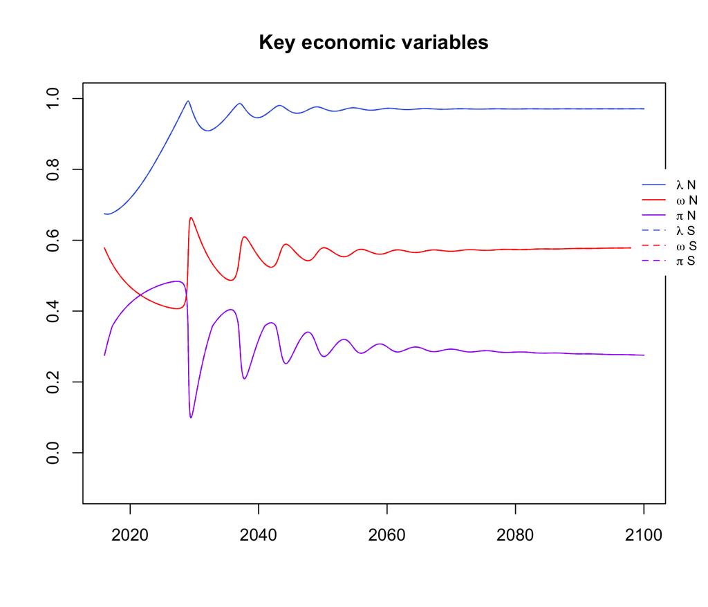

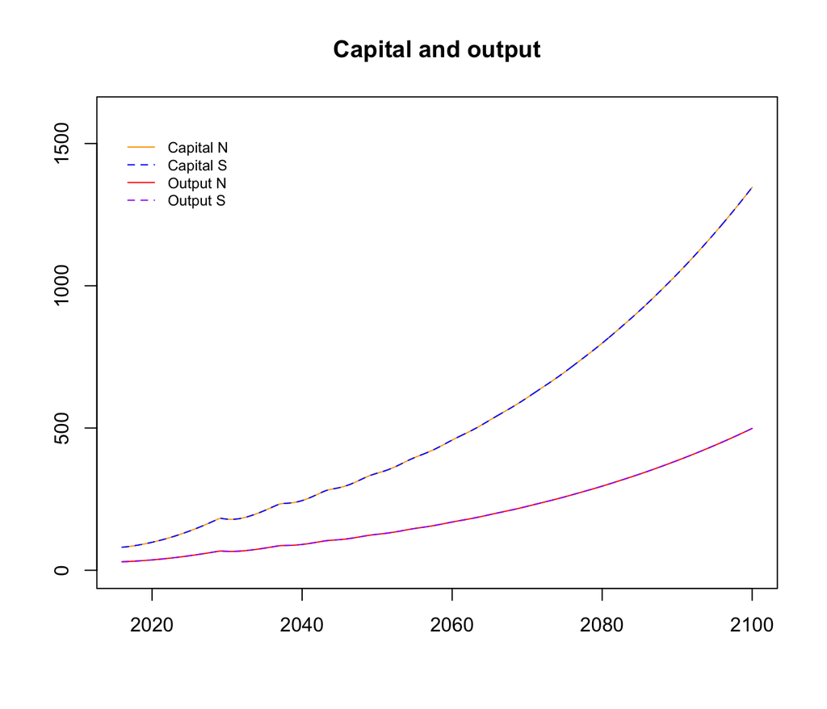

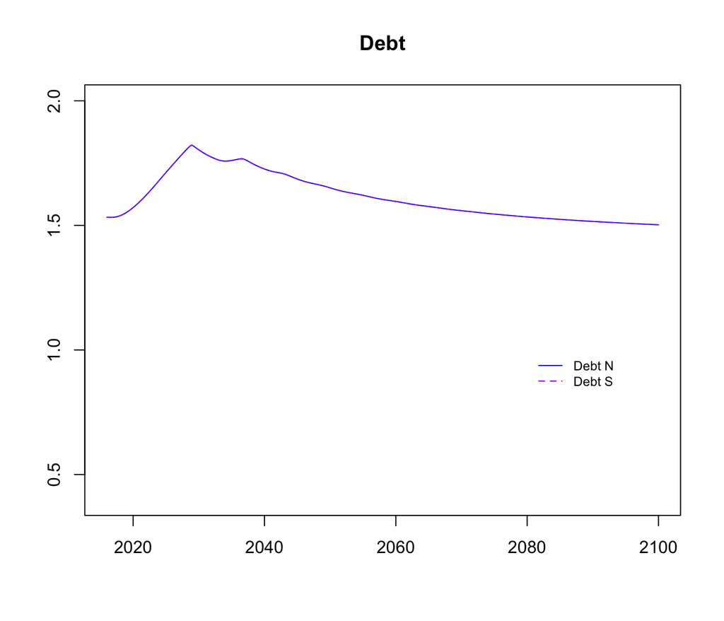

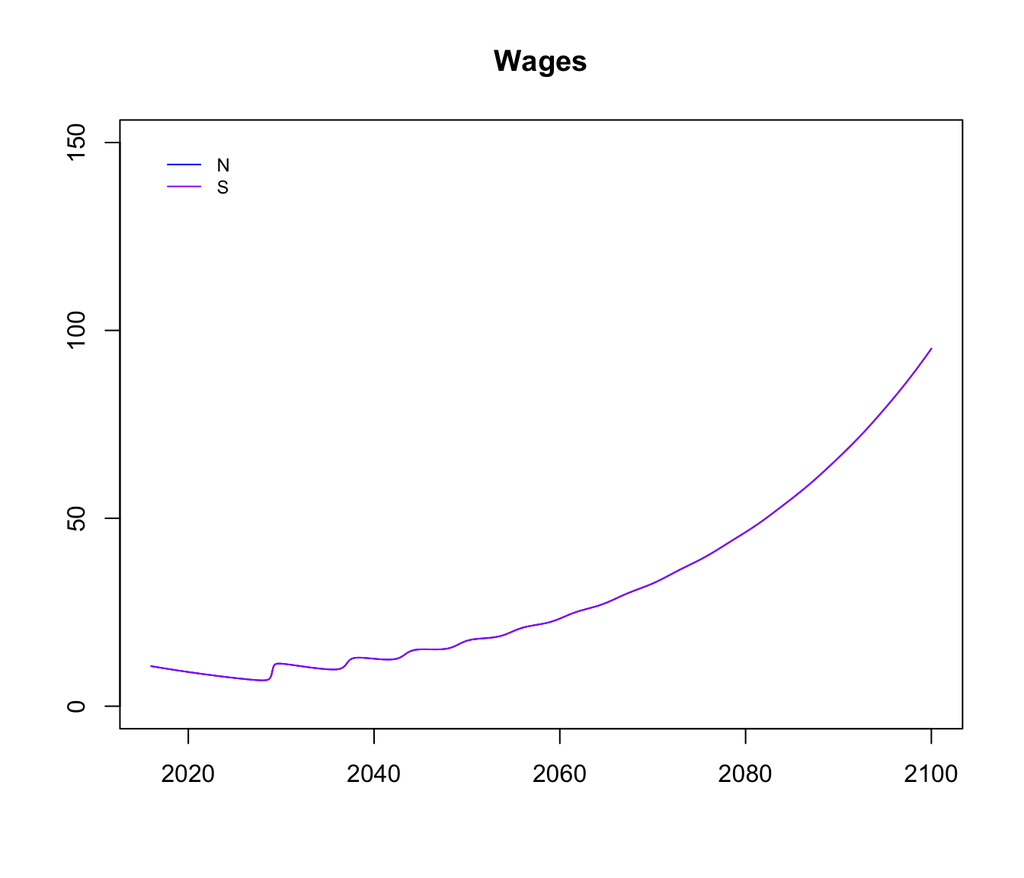

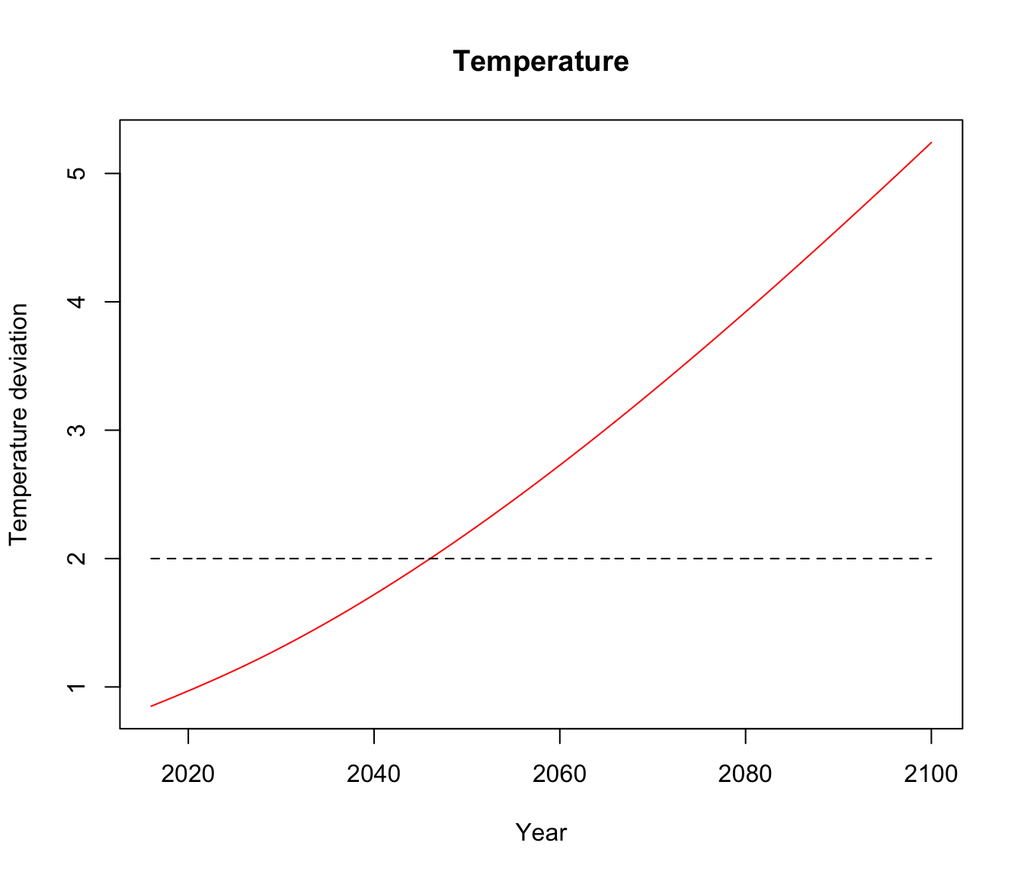

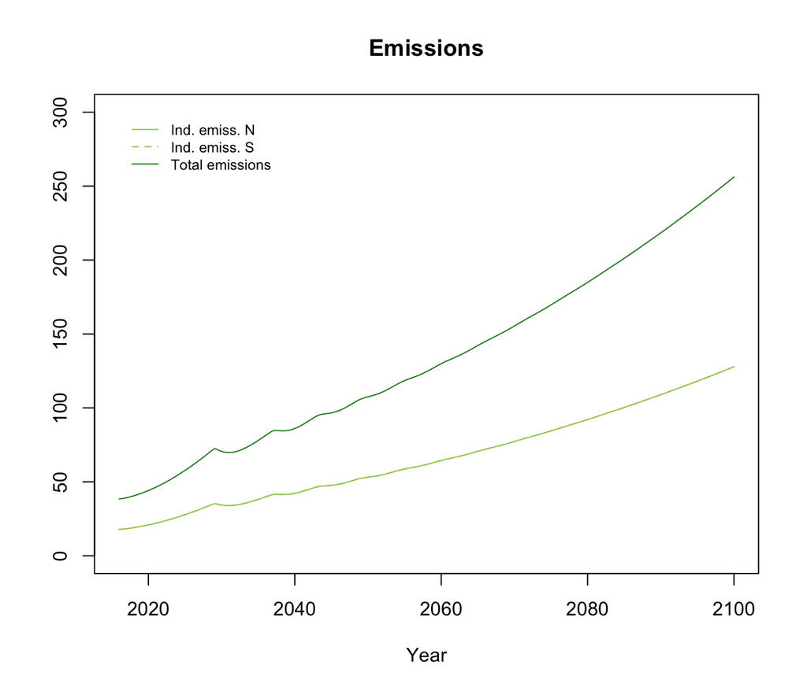

Here is what happens if you differentiate the regions. Below I set up and run another simulation with differentiated initial conditions.

**BMB**: can you work out a way to replace only selected values, or to be clearer about what’s changed?

```r
# Set initial conditions
IC <- c(
  ### Separated
  # North
  Y_N       =  40,       # global GDP, in trillions of USD
  d_N       =  1,        # private debt ratio of the economy
  lambda_N  =  0.75,     # employment rate of the global economy
  omega_N   =  0.5782,   # wage share of the economy
  N_N       =  2.4127,   # Workforce of the (world) economy, in billions /2
  g_sigma_N =  -0.0105,  # Growth rate of the emissions intensity of the economy
  n_N       =  0.04,     # Emissions reduction rate
  E_ind_N   =  17.925,   # Industrial CO2-e emissions, in Gt CO2-e

  # South
  Y_S       =  20,       # global GDP, in trillions of USD
  d_S       =  0.5,      # private debt ratio of the economy
  lambda_S  =  0.55,     # employment rate of the global economy
  omega_S   =  0.5782,   # wage share of the economy
  N_S       =  2.4127,   # Workforce of the (world) economy, in billions /2
  g_sigma_S =  -0.0105,  # Growth rate of the emissions intensity of the economy
  n_S       =  0.02,     # Emissions reduction rate
  E_ind_S   =  17.925,   # Industrial CO2-e emissions, in Gt CO2-e

  # Unique
  CO2_AT   =  851,      # CO2-e concentration in the atmosphere layer, in Gt C
  CO2_UP   =  460,      # CO2-e concentration in the biosphere and upper ocean layer, in Gt C
  CO2_LO   =  1740,     # CO2-e concentration in the deep ocean layer, in Gt C
  E_land   =  2.6,      # Exogenous land use change CO2-e emissions, in Gt CO2-e
  p        =  1,        # Composite good price level
  p_BS     =  547.22,   # Backstop technology price level
  Temp     =  0.85,     # Temperature in the atmosphere, biosphere, and upper ocean layer, in degrees Celsius
  Temp_LO  =  0.0068    # Temperature in the deep ocean layer, in degrees Celsius
)

#=================================================================================
# Set up simulation
Time <- c(
  start         =     2016,
  end           =     2100,
  step          =     0.05,
  start_p_Car_N =     2016,
  start_p_Car_S =     2016
)

Active <- list(
  Damage_N     =   'None',      # None / Nordhaus / Weitzman / Stern
  Damage_S     =   'None',      # None / Nordhaus / Weitzman / Stern
  Damage_K     =    0,          # Fraction of damages allocated to capital
  Temperature  =    TRUE,       # T / F
  Lab_Prod_N   =   'constant',  # constant / Burke
  Lab_Prod_S   =   'constant',  # constant / Burke
  p_Car_N      =   'None',      # None / Low / Medium / High / Canada
  s_A_N        =   0,           # fraction of abatement costs subsidized by government
  p_Car_S      =   'None',      # None / Low / Medium / High / Canada
  s_A_S        =   0,           # fraction of abatement costs subsidized by government
  bal_budg     =   FALSE,       # T / F
  Phillips     =   'asymptotic' # linear / asymptotic
)

#================================================================================
## Run a scenario
Sim2 <- simulation(time      = Time,
                   init_sim  = IC,
                   pars      = Params,
                   active    = Active)
```

And here are the same plots as above but for the differentiated regions.

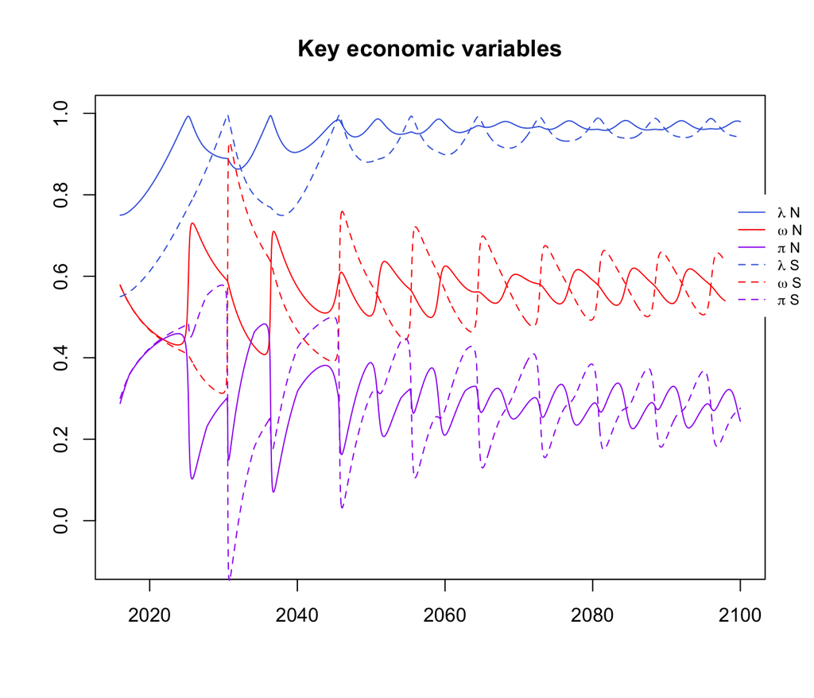

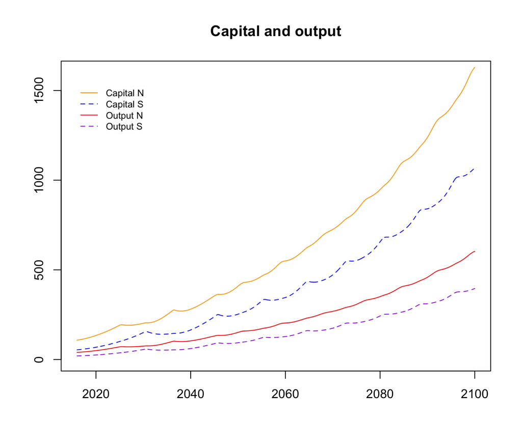

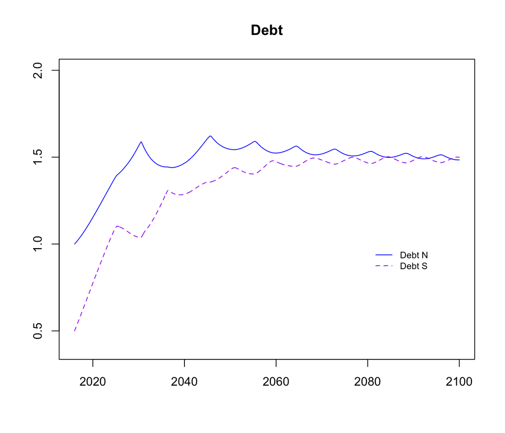

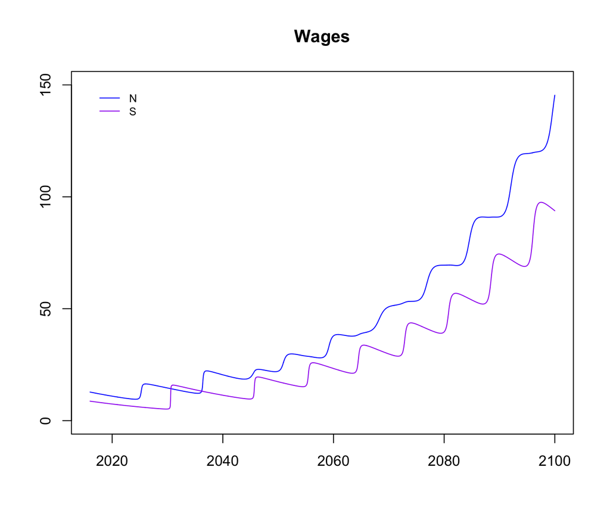

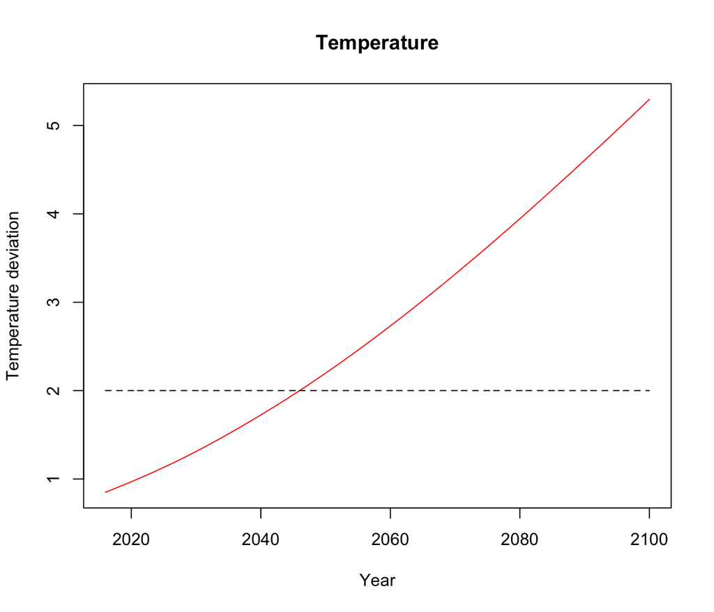

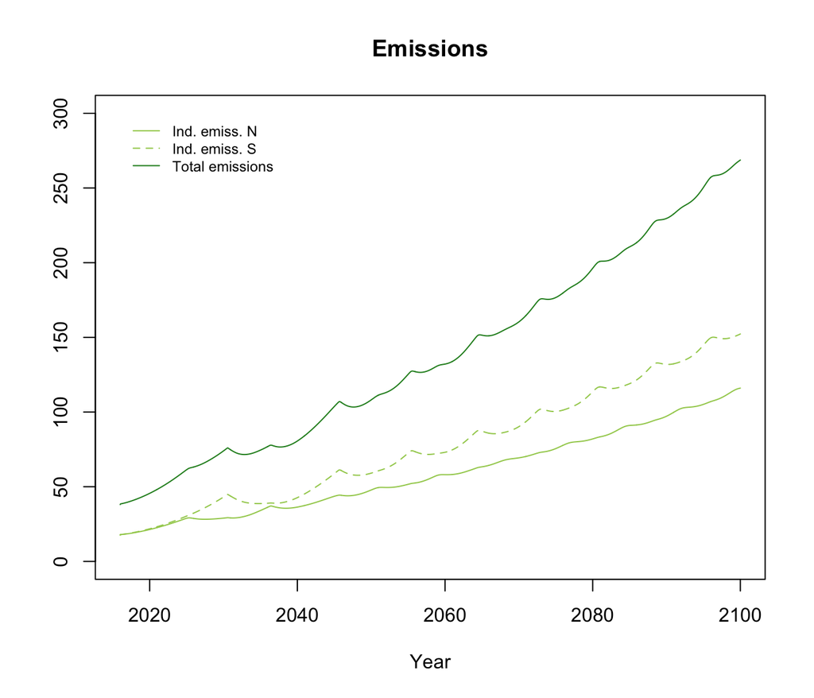